# R Notebook

```r
# packages
library(tswge)
library(vars)
library(RColorBrewer) #for "fan" forecasts
library(GGally)
library(quantmod)
library(nnfor)
library(dplyr)
library(lubridate)
# if there is an issue with TSWGE - use this
### gitHub TSWGE
# library(devtools)
# install_github("BivinSadler/tswge")
# # WHEN PROMPTED FOR UPDATES = SELECT 3 = NONE
# # make sure to terminate R and restart session
# library(tswge)
# # exists('roll.win.rmse.wge')
### If this returns = TRUE then you have the GitHub version of TSWGE, and need the long-hand ASE function call


# If it is false = then you are using the current TSWGE package  from:
# # remove.packages('tswge')
# # install.packages('tswge')
```

```r
set.seed(17)
setwd("~/00 SMU/07 time series/project/datasources")
walSales = read.csv("walmart_sales.csv",header=T,stringsAsFactors = TRUE)
inDates = read.csv("dates_in.csv",header=T)
walStock = read.csv("walmart_stock.csv",header=T,stringsAsFactors = TRUE)
```

```r
inDates2 = inDates %>%
  select(FISCAL_WEEK_END
         ,DATE_ID
         ,FISCAL_YEAR_ID
         ,FISCAL_YEAR_START)
inDates = inDates2

inDates$Date = inDates$DATE_ID
length(walSales$Weekly_Sales)
```

```
[1] 6435
```

```r
stock_df = merge(x=walStock,y=inDates,all.x=TRUE)
head(stock_df)
```

|  | Date | Open | High | Low | Close | Volume | Name | FISCAL_WEEK_END | DATE_ID | FISCAL_YEAR_ID | FISCAL_YEAR_START |
| --- | --- | --- | --- | --- | --- | --- | --- | --- | --- | --- | --- |
| 1 | 1/10/2006 | 45.50 | 46.03 | 45.46 | 45.86 | 13422500 | WMT | 1/13/2006 | 1/10/2006 | 2,006 | 12/22/2005 |
| 2 | 1/10/2007 | 47.05 | 47.62 | 46.51 | 47.28 | 13312200 | WMT | 1/12/2007 | 1/10/2007 | 2,007 | 12/22/2006 |
| 3 | 1/10/2008 | 47.10 | 48.77 | 47.10 | 48.40 | 35694739 | WMT | 1/11/2008 | 1/10/2008 | 2,008 | 12/22/2007 |
| 4 | 1/10/2011 | 53.65 | 54.11 | 53.54 | 53.73 | 10479403 | WMT | 1/14/2011 | 1/10/2011 | 2,011 | 12/22/2010 |
| 5 | 1/10/2012 | 59.43 | 59.71 | 58.98 | 59.04 | 6907461 | WMT | 1/13/2012 | 1/10/2012 | 2,012 | 12/22/2011 |
| 6 | 1/10/2013 | 68.66 | 69.03 | 67.72 | 68.36 | 11454308 | WMT | 1/11/2013 | 1/10/2013 | 2,013 | 12/22/2012 |

```r
stock_df$Date = as.Date(mdy(stock_df$Date))

stock_weekly_stg = data.frame(stock_df %>%
                                group_by (FISCAL_WEEK_END) %>%
                                summarize(
                                  avgOpen = mean(Open, na.rm=TRUE),
                                  avgHigh = mean(High, na.rm=TRUE),
                                  avgLow = mean(Low, na.rm=TRUE),
                                  avgClose = mean(Close, na.rm=TRUE),
                                  avgVolume = mean(Volume, na.rm=TRUE),
                                  FISCAL_YEAR_ID = max(FISCAL_YEAR_ID)
                                ))
head(stock_weekly_stg)
```

|  | FISCAL_WEEK_END | avgOpen | avgHigh | avgLow | avgClose | avgVolume | FISCAL_YEAR_ID |
| --- | --- | --- | --- | --- | --- | --- | --- |
| 1 | 1/1/2010 | 53.9850 | 54.2275 | 53.705 | 53.960 | 7812949 | 2,010 |
| 2 | 1/1/2016 | 61.1425 | 61.5775 | 61.035 | 61.335 | 6399296 | 2,016 |
| 3 | 1/10/2014 | 78.4460 | 78.6780 | 77.668 | 78.124 | 5876970 | 2,014 |
| 4 | 1/11/2008 | 46.7040 | 47.6540 | 46.262 | 47.110 | 26084259 | 2,008 |
| 5 | 1/11/2013 | 68.6060 | 68.8680 | 68.096 | 68.510 | 6960953 | 2,013 |
| 6 | 1/12/2007 | 47.1700 | 47.6880 | 46.966 | 47.450 | 14620420 | 2,007 |

```r
stock_weekly = stock_weekly_stg

stock_weekly$FISCAL_WEEK_END = as.factor(stock_weekly$FISCAL_WEEK_END)
stock_weekly$FISCAL_WEEK_END = strptime(stock_weekly$FISCAL_WEEK_END, format="%m/%d/%Y")
stock_weekly$FISCAL_WEEK_END = as.Date(stock_weekly$FISCAL_WEEK_END, format="%m/%d/%Y")
str(stock_weekly)
```

```
'data.frame':   634 obs. of  7 variables:
 $ FISCAL_WEEK_END: Date, format: "2010-01-01" "2016-01-01" "2014-01-10" "2008-01-11" ...
 $ avgOpen        : num  54 61.1 78.4 46.7 68.6 ...
 $ avgHigh        : num  54.2 61.6 78.7 47.7 68.9 ...
 $ avgLow         : num  53.7 61 77.7 46.3 68.1 ...
 $ avgClose       : num  54 61.3 78.1 47.1 68.5 ...
 $ avgVolume      : num  7812949 6399296 5876970 26084259 6960953 ...
 $ FISCAL_YEAR_ID : chr  "2,010" "2,016" "2,014" "2,008" ...
```

```r
stock_weekly = stock_weekly[order(as.Date(stock_weekly$FISCAL_WEEK_END)),]
stock_weekly
```

|  | FISCAL_WEEK_END | avgOpen | avgHigh | avgLow | avgClose | avgVolume | FISCAL_YEAR_ID |
| --- | --- | --- | --- | --- | --- | --- | --- |
| 46 | 2006-01-06 | 46.07250 | 46.36000 | 45.51500 | 46.03000 | 19849700 | 2,006 |
| 7 | 2006-01-13 | 45.87600 | 46.21200 | 45.55200 | 45.85600 | 12835760 | 2,006 |
| 21 | 2006-01-20 | 45.21750 | 45.60000 | 44.79500 | 45.15750 | 16958125 | 2,006 |
| 33 | 2006-01-27 | 45.69000 | 46.11600 | 45.28200 | 45.82000 | 16637180 | 2,006 |
| 252 | 2006-02-03 | 46.23600 | 46.51000 | 45.74400 | 46.08600 | 14645740 | 2,006 |
| 216 | 2006-02-10 | 45.26000 | 45.68200 | 44.97800 | 45.33400 | 12378760 | 2,006 |
| 228 | 2006-02-17 | 46.13200 | 46.60800 | 45.75800 | 46.31600 | 11659760 | 2,006 |
| 242 | 2006-02-24 | 45.71000 | 46.03750 | 45.37750 | 45.59250 | 12441600 | 2,006 |
| 302 | 2006-03-03 | 45.27200 | 45.63600 | 45.11800 | 45.33200 | 11085460 | 2,006 |
| 265 | 2006-03-10 | 45.30400 | 45.48000 | 45.10000 | 45.24600 | 10405980 | 2,006 |

[output cut: 624 more lines]

```r
# stock_weekly$Date = as.Date(mdy(stock_weekly$Date))
head(stock_weekly)
```

|  | FISCAL_WEEK_END | avgOpen | avgHigh | avgLow | avgClose | avgVolume | FISCAL_YEAR_ID |
| --- | --- | --- | --- | --- | --- | --- | --- |
| 46 | 2006-01-06 | 46.0725 | 46.360 | 45.515 | 46.0300 | 19849700 | 2,006 |
| 7 | 2006-01-13 | 45.8760 | 46.212 | 45.552 | 45.8560 | 12835760 | 2,006 |
| 21 | 2006-01-20 | 45.2175 | 45.600 | 44.795 | 45.1575 | 16958125 | 2,006 |
| 33 | 2006-01-27 | 45.6900 | 46.116 | 45.282 | 45.8200 | 16637180 | 2,006 |
| 252 | 2006-02-03 | 46.2360 | 46.510 | 45.744 | 46.0860 | 14645740 | 2,006 |
| 216 | 2006-02-10 | 45.2600 | 45.682 | 44.978 | 45.3340 | 12378760 | 2,006 |

```r
stock_weekly %>% group_by(FISCAL_YEAR_ID) %>% summarize(count=n())
```

| FISCAL_YEAR_ID | count |
| --- | --- |
| 2,006 | 50 |
| 2,007 | 53 |
| 2,008 | 52 |
| 2,009 | 52 |
| 2,010 | 52 |
| 2,011 | 52 |
| 2,012 | 53 |
| 2,013 | 52 |
| 2,014 | 52 |
| 2,015 | 52 |

[output cut: 3 more lines]

```r
stock_weekly = stock_weekly[which(stock_weekly$FISCAL_YEAR_ID == '2,010'|
                                    stock_weekly$FISCAL_YEAR_ID == '2,011'|
                                    stock_weekly$FISCAL_YEAR_ID == '2,012'), ]
stock_weekly %>% group_by(FISCAL_YEAR_ID) %>% summarize(count=n())
```

| FISCAL_YEAR_ID | count |
| --- | --- |
| 2,010 | 52 |
| 2,011 | 52 |
| 2,012 | 53 |

```r
head(stock_weekly, n=50)
```

|  | FISCAL_WEEK_END | avgOpen | avgHigh | avgLow | avgClose | avgVolume | FISCAL_YEAR_ID |
| --- | --- | --- | --- | --- | --- | --- | --- |
| 190 | 2009-12-25 | 53.3175 | 53.6600 | 53.2000 | 53.4150 | 9623868 | 2,010 |
| 1 | 2010-01-01 | 53.9850 | 54.2275 | 53.7050 | 53.9600 | 7812949 | 2,010 |
| 50 | 2010-01-08 | 53.6960 | 53.9940 | 53.3880 | 53.6840 | 14189456 | 2,010 |
| 11 | 2010-01-15 | 54.2380 | 54.7560 | 53.8260 | 54.3680 | 15051548 | 2,010 |
| 25 | 2010-01-22 | 53.7150 | 53.9350 | 53.0650 | 53.4375 | 15842965 | 2,010 |
| 37 | 2010-01-29 | 53.3080 | 53.6900 | 52.9040 | 53.1860 | 16404526 | 2,010 |
| 256 | 2010-02-05 | 53.5180 | 53.9660 | 53.2000 | 53.5320 | 15396590 | 2,010 |
| 220 | 2010-02-12 | 53.2200 | 53.4440 | 52.8540 | 53.0800 | 11871607 | 2,010 |
| 232 | 2010-02-19 | 53.3300 | 53.7625 | 53.1325 | 53.6450 | 18963477 | 2,010 |
| 246 | 2010-02-26 | 53.7380 | 54.0940 | 53.4040 | 53.9180 | 13264509 | 2,010 |

[output cut: 40 more lines]

```r
stock_weekly
```

|  | FISCAL_WEEK_END | avgOpen | avgHigh | avgLow | avgClose | avgVolume | FISCAL_YEAR_ID |
| --- | --- | --- | --- | --- | --- | --- | --- |
| 190 | 2009-12-25 | 53.31750 | 53.66000 | 53.2000 | 53.41500 | 9623868 | 2,010 |
| 1 | 2010-01-01 | 53.98500 | 54.22750 | 53.7050 | 53.96000 | 7812949 | 2,010 |
| 50 | 2010-01-08 | 53.69600 | 53.99400 | 53.3880 | 53.68400 | 14189456 | 2,010 |
| 11 | 2010-01-15 | 54.23800 | 54.75600 | 53.8260 | 54.36800 | 15051548 | 2,010 |
| 25 | 2010-01-22 | 53.71500 | 53.93500 | 53.0650 | 53.43750 | 15842965 | 2,010 |
| 37 | 2010-01-29 | 53.30800 | 53.69000 | 52.9040 | 53.18600 | 16404526 | 2,010 |
| 256 | 2010-02-05 | 53.51800 | 53.96600 | 53.2000 | 53.53200 | 15396590 | 2,010 |
| 220 | 2010-02-12 | 53.22000 | 53.44400 | 52.8540 | 53.08000 | 11871607 | 2,010 |
| 232 | 2010-02-19 | 53.33000 | 53.76250 | 53.1325 | 53.64500 | 18963477 | 2,010 |
| 246 | 2010-02-26 | 53.73800 | 54.09400 | 53.4040 | 53.91800 | 13264509 | 2,010 |

[output cut: 147 more lines]

```r
# stock_weekly$FISCAL_WEEK_END = as.Date(mdy(stock_df$FISCAL_WEEK_END))
```

### UNIVARIATE ANALYSIS OF STOCK DATA

## OBSERVATIONS

Obs 01. The realization shows a wandering behavior.

Obs 02. Sample autocorrelations plot is damping and there is a peak at 0 in Frequency plot.

### Step 01. plot the data

# confirm data are not white noise

```r
aic5.wge(stock_weekly$avgClose)
```

```
---------WORKING... PLEASE WAIT...
```

```
Five Smallest Values of  aic
```

|  | p | q | aic |
| --- | --- | --- | --- |
| 7 | 2 | 0 | 0.03009489 |
| 5 | 1 | 1 | 0.03117087 |
| 6 | 1 | 2 | 0.04277490 |
| 8 | 2 | 1 | 0.04277936 |
| 10 | 3 | 0 | 0.04277979 |

```r
plotts.wge(stock_weekly$avgClose)
plotts.sample.wge(stock_weekly$avgClose)
```

[output not shown]

[output not shown]

# peaks at 0

```r
pacf(stock_weekly$avgClose)

priceClose = parzen.wge(stock_weekly$avgClose)
```

[output not shown]

```r
# priceClose$freq[findPeaks(priceClose$pzgram)]
```

TRAIN / TEST SPLIT DATA

```r
# create train, test data set (future note: would want to add validate set)
# length(stock_weekly$avgClose)
stock_train = stock_weekly[1:142,]
stock_test = stock_weekly[143:157,]
```

### MODEL 01. UNIVARIATE AR(1)

# Model ID (also, confirm the data are not white noise)

```r
aic5.wge(stock_train$avgClose)
```

```
---------WORKING... PLEASE WAIT...


Error in aic calculation at 1 1
Error in aic calculation at 1 2
Error in aic calculation at 2 0
Error in aic calculation at 2 1
```

```
Error in aic calculation at 3 0
Error in aic calculation at 3 1
Error in aic calculation at 3 2
Error in aic calculation at 4 0
Error in aic calculation at 4 1
```

```
Error in aic calculation at 5 0
Error in aic calculation at 5 1
Five Smallest Values of  aic
```

|  | p | q | aic |
| --- | --- | --- | --- |
| 4 | 1 | 0 | 0.01782852 |
| 9 | 2 | 2 | 0.02697534 |
| 18 | 5 | 2 | 0.61341430 |
| 15 | 4 | 2 | 0.81513427 |
| 3 | 0 | 2 | 1.66137084 |

The above code provides evidence that the data are not consistent with simply white noise. White noise would return p = 0, and q = 0.

AIC scores suggest a correlation structure of p=1, q=0, an AR(1) model.

Next, we estimate the model parameters using AIC selected model (ML Estimates).

```r
mod01est = est.arma.wge(stock_train$avgClose,p=1,q=0)
```

```
Coefficients of AR polynomial:
0.9944

                           AR Factor Table
Factor                 Roots                Abs Recip    System Freq
1-0.9944B              1.0057               0.9944       0.0000
```

```r
mean(stock_train$avgClose)
```

```
[1] 56.50996
```

```r
mod01est$phi
```

```
[1] 0.9943521
```

```r
mod01est$theta
```

```
[1] 0
```

```r
mod01est$avar
```

```
[1] 0.9897128
```

# Equation for Model 01

> (1 - 0.994B) (X - 56.50996) = a(t)

# white noise evaluation of residuals

## Check 01. Visual

A visual check of the residuals’ autocorrelation shows some evidence that the variance may not be consistent with white noise. (We would expect to see about 1 in 20 outside the lines in the plot.) Noting this, we will use the Ljung-Box test to check the residuals for white noise.

Desired result = residuals consistent with white noise. We want to be sure that the noise between points in the model is not correlated. If we still have correlation, we will difference the data again.

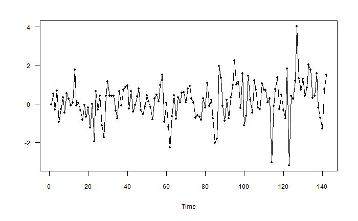

```r
plotts.wge(mod01est$res)
```

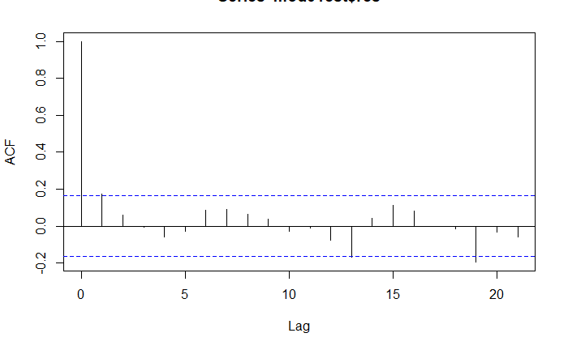

```r
acf(mod01est$res)
```

## Check 02. Ljung Box test

```r
ljung.wge(mod01est$res, p=1, q=0)
```

```
Obs 0.1751197 0.05975155 -0.006073416 -0.05655032 -0.02982486 0.08578529 0.08848929 0.06272136 0.03931592 -0.02626589 -0.009237226 -0.0771984 -0.1683371 0.04007817 0.1103194 0.08178261 -0.002171918 -0.01375529 -0.1934449 -0.03209661 -0.05888482 0.07800072 0.04727457 0.05803131
$test
[1] "Ljung-Box test"

$K
[1] 24

$chi.square
[1] 26.57821

$df
[1] 23

$pval
[1] 0.2743372
```

```r
ljung.wge(mod01est$res, p=1, q=0, K=48)
```

```
Obs 0.1751197 0.05975155 -0.006073416 -0.05655032 -0.02982486 0.08578529 0.08848929 0.06272136 0.03931592 -0.02626589 -0.009237226 -0.0771984 -0.1683371 0.04007817 0.1103194 0.08178261 -0.002171918 -0.01375529 -0.1934449 -0.03209661 -0.05888482 0.07800072 0.04727457 0.05803131 0.09859932 -0.03831729…
$test
[1] "Ljung-Box test"

$K
[1] 48

$chi.square
[1] 46.67704

$df
[1] 47

$pval
[1] 0.4858478
```

# forecast last 5 values using estimated parameters from above

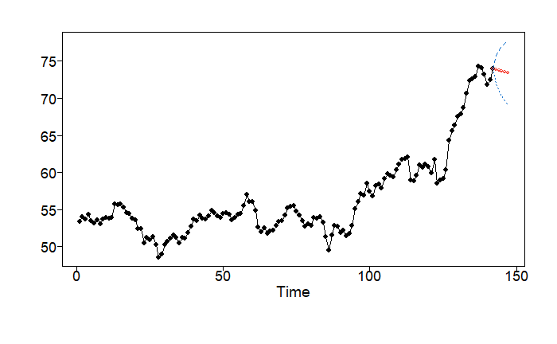

```r
mod01preds = fore.arma.wge(stock_train$avgClose,phi = mod01est$phi,
                           theta = mod01est$theta,n.ahead = 5, lastn=FALSE)
```

```r
ase01ST = mean((mod01preds$f - stock_test$avgClose[1:5])^2)
ase01ST
```

```
[1] 0.8787013
```

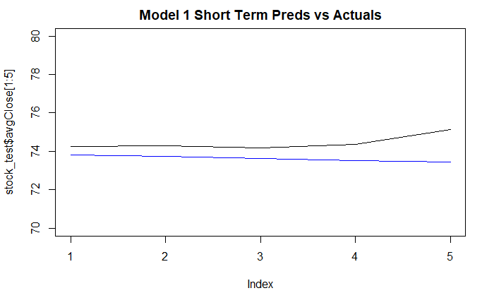

```r
# # plot forecast preds against actuals
plot(stock_test$avgClose[1:5], type='l',main = 'Model 1 Short Term Preds vs Actuals',
     ylim = c(70,80))
lines(seq(1,5), mod01preds$f, col = 'blue')
```

```r
# plot(stock_weekly$avgClose[1:147], type='l',main = 'Model 1 Short Term Preds vs Actuals')
# lines(seq(143,147), mod01preds$f, col = 'blue')
```

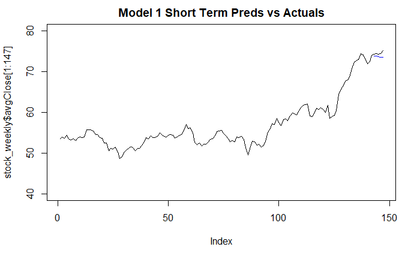

```r
plot(stock_weekly$avgClose[1:147], type='l',main = 'Model 1 Short Term Preds vs Actuals',
     ylim = c(40, 80))
lines(seq(143,147), mod01preds$f, col = 'blue')
```

### MODEL 02. ARIMA(1,2,1)

We notice that the parameter estimate for our AR(1) model has an absolute reciprocal value very close to 1, which is very nearly nonstationary.

Difference the data (Box-Jenkins method to help with unit roots. High-pass filter.) One way to address nonstaionary behavior due to a root on the unit circle is to difference the data until they appear stationary.

```r
# take first difference of the data
mod02df = artrans.wge(stock_train$avgClose, 1)
plotts.sample.wge(mod02df)
```

[output not shown]

[output not shown]

```r
aic5.wge(mod02df)
```

```
---------WORKING... PLEASE WAIT...
```

```
Five Smallest Values of  aic
```

|  | p | q | aic |
| --- | --- | --- | --- |
| 4 | 1 | 0 | -0.03199100 |
| 2 | 0 | 1 | -0.02999927 |
| 3 | 0 | 2 | -0.01876255 |
| 7 | 2 | 0 | -0.01826633 |
| 5 | 1 | 1 | -0.01811745 |

After taking the first difference of the data, still shows us AR(1).

Difference the data again.

[output not shown]

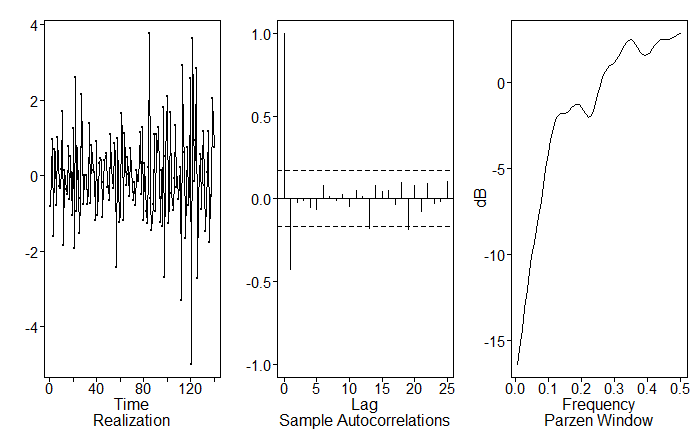

```r
# pass in the differenced data
mod02df1 = artrans.wge(mod02df, 1)
plotts.sample.wge(mod02df1,arlimit=TRUE)
```

```r
aic5.wge(mod02df1)
```

```
---------WORKING... PLEASE WAIT...


Five Smallest Values of  aic
```

|  | p | q | aic |
| --- | --- | --- | --- |
| 5 | 1 | 1 | -0.03503141 |
| 2 | 0 | 1 | -0.01736227 |
| 9 | 2 | 2 | 0.02017878 |
| 16 | 5 | 0 | 0.15004340 |
| 12 | 3 | 2 | 0.18494663 |

```r
mod02est = est.arma.wge(mod02df1,p=1, q = 1)
```

```
Coefficients of AR polynomial:
0.1476

                           AR Factor Table
Factor                 Roots                Abs Recip    System Freq
1-0.1476B              6.7731               0.1476       0.0000




Coefficients of MA polynomial:
1.0000

                              MA FACTOR TABLE
Factor                 Roots                Abs Recip    System Freq
1-1.0000B              1.0000               1.0000       0.0000
```

```r
mean(mod02df1)
```

```
[1] 0.006225
```

```r
mod02est$phi
```

```
[1] 0.1476436
```

```r
mod02est$theta
```

```
[1] 0.999998
```

```r
mod02est$avar
```

```
[1] 0.9250675
```

# Note: if mean is positive, subtract from final model estimation.

# Equation for Model 02. ARIMA(1,2,1)

> (1 - 0.1476B)((1 - B)^2)(X(t) - 0.006225) = (1 - B)a(t)

When we originally ran this, our MA term was 0.999B. A second pass suggests that maybe we should address the unit root in the MA component.

Options for additional analysis could be to test another AR(p) model with additional differencing, layering in seasonality, or applying a moving average filter to the data.

# White noise evaluation: Model 02.

## Check 01. Visual

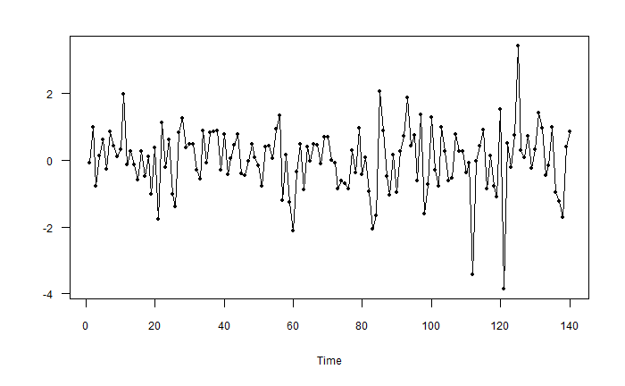

```r
plotts.wge(mod02est$res)
```

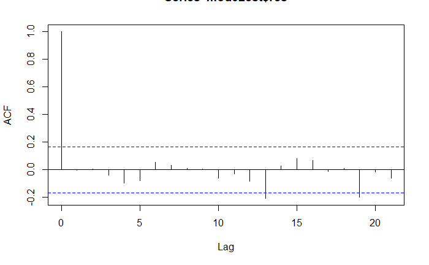

```r
acf(mod02est$res)
```

```r
ljung.wge(mod01est$res, p=1, q=1) # K=24, p-value > 0.05, fail to reject whitenoise
```

```
Obs 0.1751197 0.05975155 -0.006073416 -0.05655032 -0.02982486 0.08578529 0.08848929 0.06272136 0.03931592 -0.02626589 -0.009237226 -0.0771984 -0.1683371 0.04007817 0.1103194 0.08178261 -0.002171918 -0.01375529 -0.1934449 -0.03209661 -0.05888482 0.07800072 0.04727457 0.05803131
$test
[1] "Ljung-Box test"

$K
[1] 24

$chi.square
[1] 26.57821

$df
[1] 22

$pval
[1] 0.2276859
```

```r
ljung.wge(mod01est$res, p=1, q=1, K=48) # K=24, p-value > 0.05
```

```
Obs 0.1751197 0.05975155 -0.006073416 -0.05655032 -0.02982486 0.08578529 0.08848929 0.06272136 0.03931592 -0.02626589 -0.009237226 -0.0771984 -0.1683371 0.04007817 0.1103194 0.08178261 -0.002171918 -0.01375529 -0.1934449 -0.03209661 -0.05888482 0.07800072 0.04727457 0.05803131 0.09859932 -0.03831729…
$test
[1] "Ljung-Box test"

$K
[1] 48

$chi.square
[1] 46.67704

$df
[1] 46

$pval
[1] 0.4444351
```

# SHORT TERM FORECAST

Predictions for last 5 values using estimated parameters from above.

```
s= 0
ptot.res= 2
phitot.res 2 -1
ptot.fore= 3
phitot.fore 2.147644 -1.295287 0.1476436
```

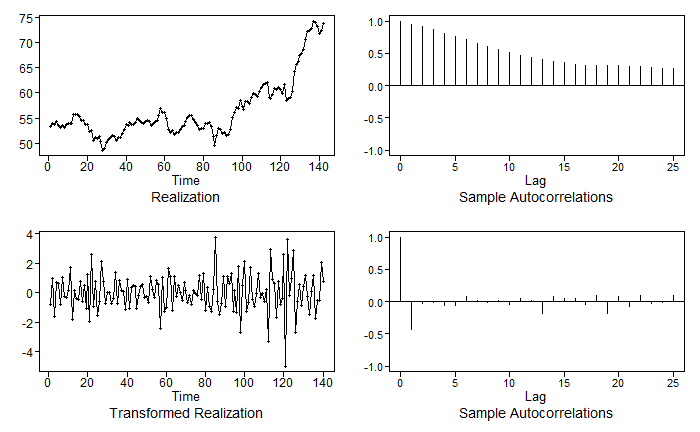

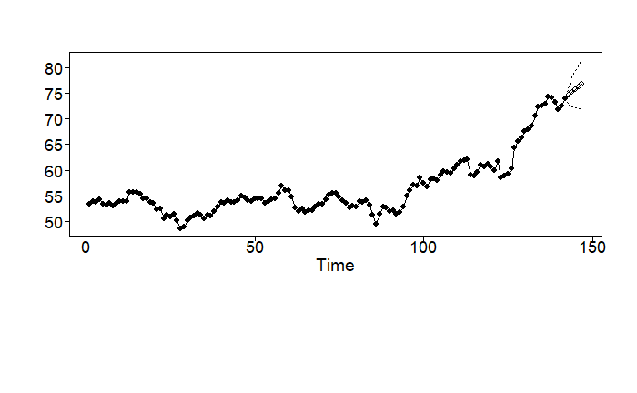

```r
mod02preds = fore.aruma.wge(stock_train$avgClose,phi = mod02est$phi, d=2,
                           theta = mod02est$theta,n.ahead = 5, lastn=FALSE)
```

```r
ase02ST = mean((mod02preds$f - stock_test$avgClose[1:5])^2)
ase02ST
```

```
[1] 1.953272
```

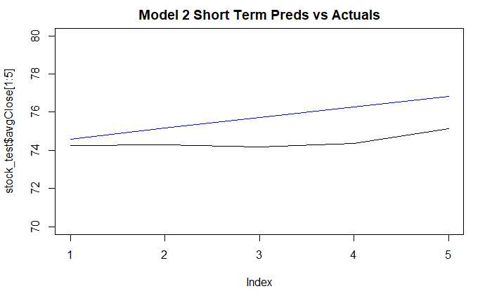

```r
# # plot forecast preds against actuals
plot(stock_test$avgClose[1:5], type='l',main = 'Model 2 Short Term Preds vs Actuals',
     ylim = c(70,80))
lines(seq(1,5), mod02preds$f, col = 'blue')
```

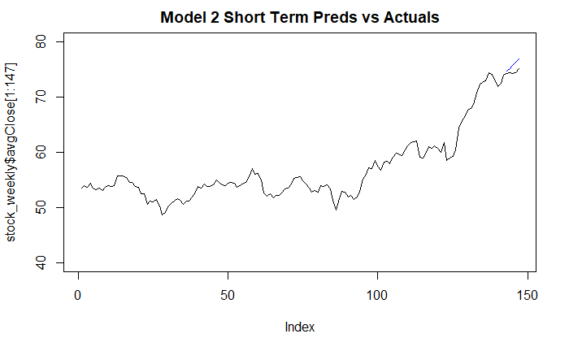

```r
plot(stock_weekly$avgClose[1:147], type='l',main = 'Model 2 Short Term Preds vs Actuals',
     ylim = c(40, 80))
lines(seq(143,147), mod02preds$f, col = 'blue')
```

LONG TERM FORECASTS

Model 1: AR(1): Long term forecasts

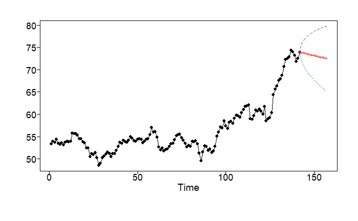

```r
# Long term forecast Model 1
mod01predsLT = fore.arma.wge(stock_train$avgClose,phi = mod01est$phi,
                           theta = mod01est$theta, n.ahead = 15, limits = T, lastn=FALSE)
```

Model 1: AR(1): Long term forecasts: ASE

```r
ase01LT = mean((mod01predsLT$f - stock_weekly$avgClose[143:157])^2)
ase01LT
```

```
[1] 4.236968
```

Model 1: AR(1): Long term forecasts: Predictions vs actuals

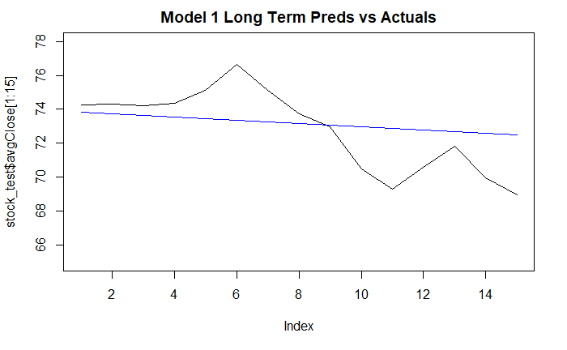

```r
# # plot forecast preds against actuals
plot(stock_test$avgClose[1:15], type='l',main = 'Model 1 Long Term Preds vs Actuals',
     ylim = c(65,78))
lines(seq(1,15), mod01predsLT$f, col = 'blue')
```

Model 1: AR(1): Long term forecasts: Predictions vs actuals

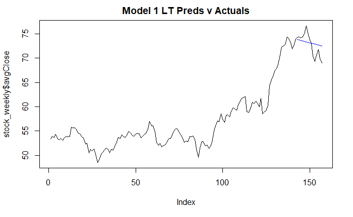

```r
# # plot forecast preds against actuals
plot(stock_weekly$avgClose, type='l',main = 'Model 1 LT Preds v Actuals')
lines(seq(143,157), mod01predsLT$f, col = 'blue')
```

Model 2. ARIMA(1,2,1): Long term forecasts

```
s= 0
ptot.res= 2
phitot.res 2 -1
ptot.fore= 3
phitot.fore 2.147644 -1.295287 0.1476436
```

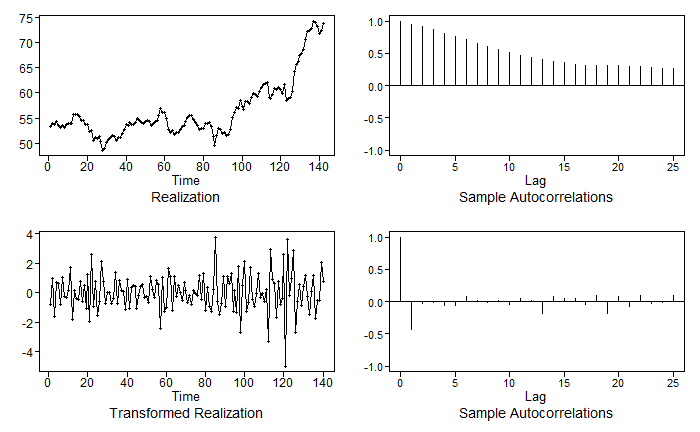

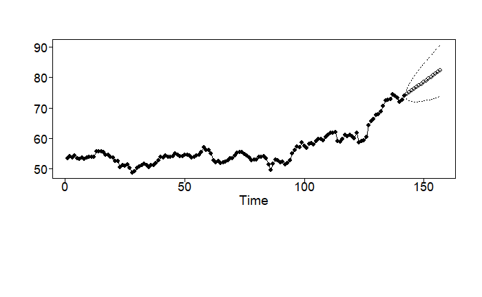

```r
# Long term forecast Model 2
mod02predsLT = fore.aruma.wge(stock_train$avgClose, phi = mod02est$phi, d = 2,
                           theta = mod02est$theta, n.ahead = 15, limits = T, lastn=FALSE)
```

Model 2. ARIMA(1,2,1): Long term forecasts: ASE

```r
ase02LT = mean((mod02predsLT$f - stock_weekly$avgClose[143:157])^2)
ase02LT
```

```
[1] 52.61042
```

Model 2. ARIMA(1,2,1): Long term forecasts: Predictions vs actuals

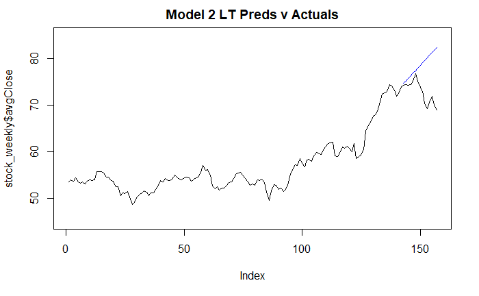

```r
# # plot forecast preds against actuals
plot(stock_weekly$avgClose, type='l',main = 'Model 2 LT Preds v Actuals',
      ylim = c(45,85))
lines(seq(143,157), mod02predsLT$f, col = 'blue')
```

Model 2 has very poor performance. We are forecasting the trend to continue, when it very clearly does not. Further assessment of the data or adding aditional features may be helpful for our model.

### ROLLING WINDOWS

ROLLING WINDOW ASE FUNCTION

```r
roll.win.ase.wge = function(series, horizon = 1, s = 0, d = 0, phis = 0, thetas = 0)
{

  trainingSize = length(phis) + length(thetas) + s + d + 1
  numwindows = length(series)-(trainingSize + horizon) + 1
  ASEHolder = numeric(numwindows)

  print(paste("Please Hold For a Moment, TSWGE is processing the Rolling Window ASE with", numwindows, "windows."))

  for( i in 1:numwindows)
  {

    invisible(capture.output(forecasts <- fore.aruma.wge(series[i:(i+(trainingSize-1))],phi = phis, theta = thetas, s = s, d = d,n.ahead = horizon)))

    ASE = mean((series[(trainingSize+i):(trainingSize+ i + (horizon) - 1)] - forecasts$f)^2)

    ASEHolder[i] = ASE

  }

  ASEHolder
  hist(ASEHolder, main = "ASEs for Individual Windows")
  WindowedASE = mean(ASEHolder)

  print("The Summary Statistics for the Rolling Window ASE Are:")
  print(summary(ASEHolder))
  print(paste("The Rolling Window ASE is: ",round(WindowedASE,3)))
  return(list(rwASE = WindowedASE, numwindows = numwindows, horizon = horizon, s = s, d = d, phis = phis, thetas = thetas))
}
```

Model 01: AR(1): Short term forecasts: Rolling window ASE

```
[1] "Please Hold For a Moment, TSWGE is processing the Rolling Window ASE with 135 windows."
```

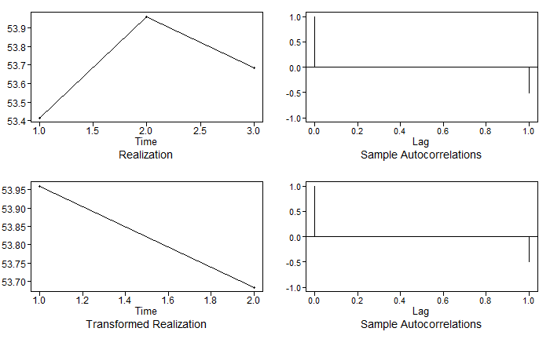

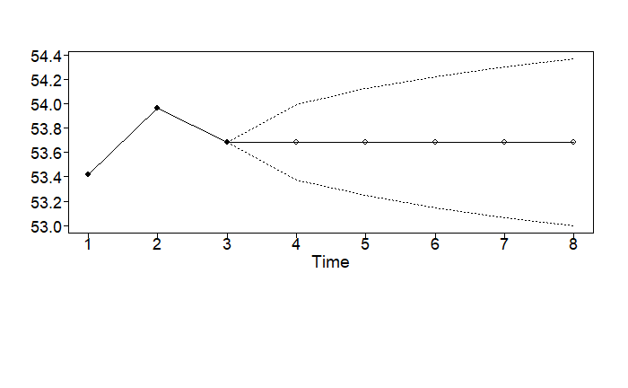

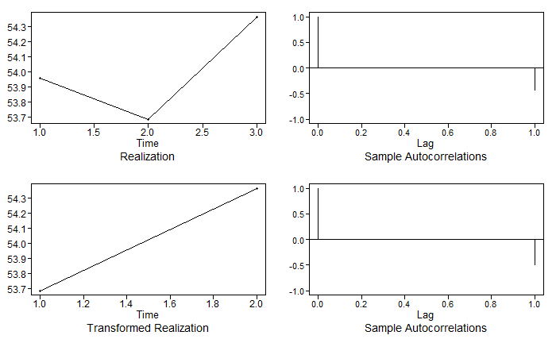

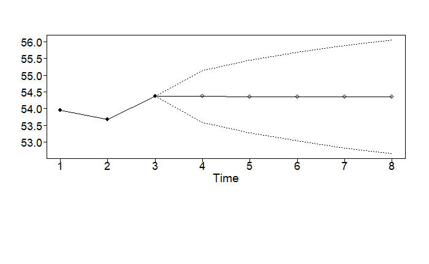

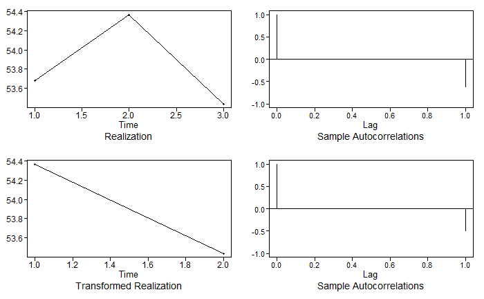

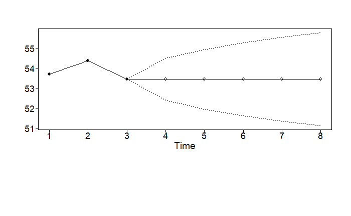

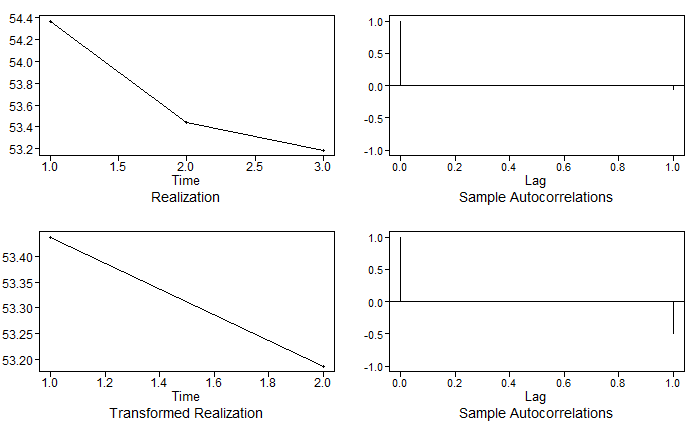

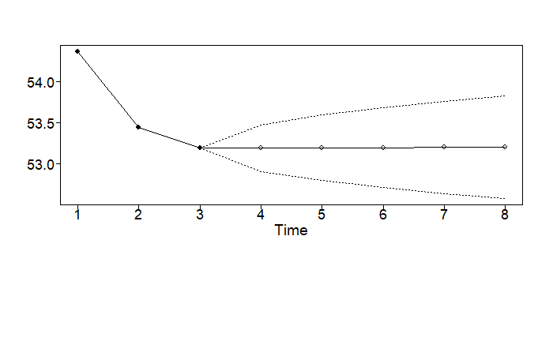

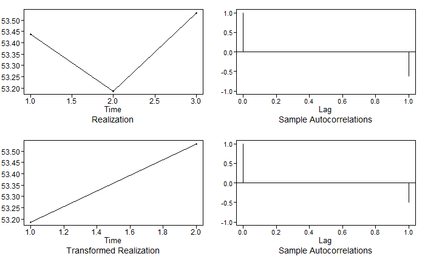

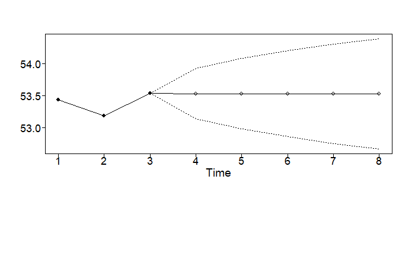

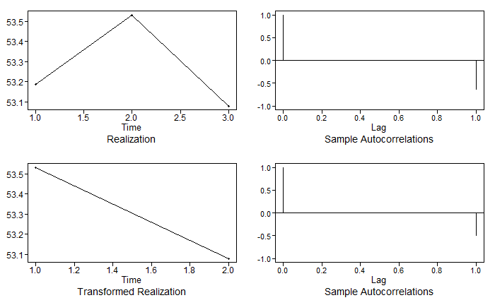

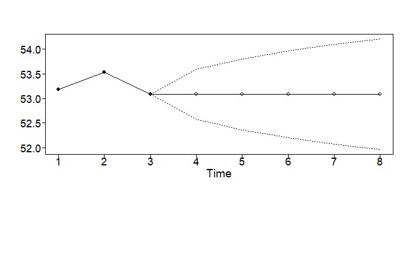

[259 more figures not shown]

```r
# function [roll.win.rmse.wge] does not exist with "regular" TSWGE (need the gitHub version for that)
# this is the ROLLING WINDOW ASE (WITH HORIZON = 5)
roll_mod01ST_ase = roll.win.ase.wge(stock_train$avgClose, horizon = 5, phis = mod01est$phi,
                           thetas = mod01est$theta)
```